# Finding structure in xkcd comics with Latent Dirichlet Allocation

Carson Sievert  
December 10th, 2013

- **xkcd** is self-proclaimed as a “a webcomic of romance, sarcasm, math, and language”.

[figure not shown]

### Each comic is a mixture of topics

[figure not shown]

- “a”, “of”, and “to” are viewed as noninformative and are removed.
- This document's content is:
  - 4/17 math
  - 5/17 romance
  - 5/17 sarcasm
  - 3/17 language
- Each document has a unique pmf over all topics.
- Each topic has a unique pmf over all words.

### Latent Dirichlet Allocation (LDA)

Let \( w_i \) denote the \( i^{th} \) token where \( i \in \{1, \dots, N\} \). For a fixed vocab \( v \in \{1, \dots, V\} \) and number of topics \( T \):

\( P(w_i = v) = \sum_{j=1}^T P(w_i = v | z_i = j)P(z_i = j) \)

- Let \( \phi_i^{(j)} = P(w_i = v | z_i = j) \) and \( \Phi \) the \( V \) by \( T \) matrix.
- For a given document \( d_i \in \{1, \dots, D\} \)), let \( \theta_j^{(d_i)} = P(z_i = j) \) and \( \Theta \) the \( T \) by \( D \) matrix.
- Assign (you guessed it) Dirichlet priors to both \( \phi \) and \( \theta \).
- With symmetric hyperparameters, we may integrate out \( \phi \) and \( \theta \) and use collapsed Gibbs to obtain samples from the target \( p(\textbf{z}|\textbf{w}, T) \) and construct \( \hat{\phi} \), \( \hat{\theta} \).

### Choosing # of Topics

- Given the hyperparameters, one can find an “optimal” number of topics via Bayesian model selection: \[ \max_T\{ p(T| \textbf{w}) \} = \max_T\{ p(\textbf{w}|T)p(T) \} \]
- Using a uniform prior for \( p(T) \) we have \( \max_T p(\textbf{w}|T) \)
- Problem: Computing \( p(\textbf{w}|T) \) requires summing over all possible assignments of words to topics (often infeasible).
- Griffiths & Steyvers ([2004](http://psiexp.ss.uci.edu/research/papers/sciencetopics.pdf)) approximate \( p(\textbf{w}|T) \) via: \[ p(w|T) \approx (\frac{1}{M} \sum^M_{m=1} p(\textbf{w} | \textbf{z}_m, T)^{-1})^{-1} \] where \( \textbf{z}_m \) is the \( m^{th} \) sample from the posterior \( p(\textbf{z} | \textbf{w}, T) \)

### Likelihood as a function of T

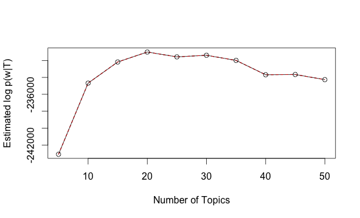

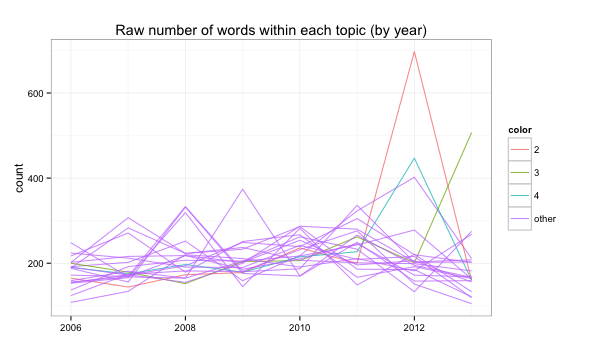

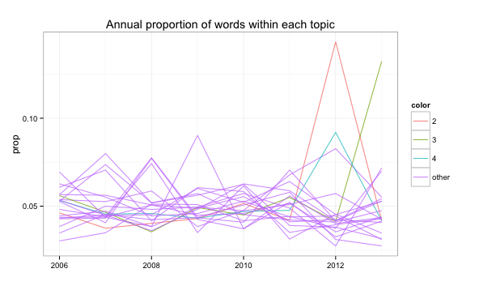

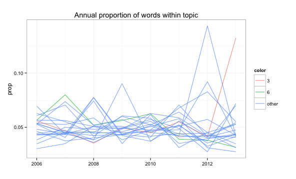

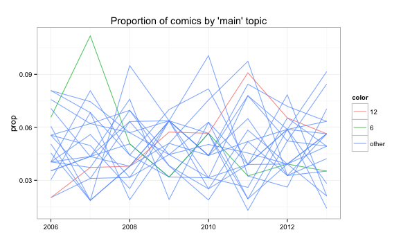

### Interpreting topics

- I need another 30 minutes to really do this justice…bear with me!
- Let's [look at](http://glimmer.rstudio.com/cpsievert/xkcd/) the most “relevant” keywords for topic 6.
- Just in case…

```r
library(shiny)
runApp(system.file("shiny", "hover", package="LDAviz"))
```